# Human Ecology: Recitation 2

20 January, 2021

## Jones and Klenow 2016

## Prompt

How do the authors account for within-country inequality?

What limits do you see in the authors’ approach?

## Prompt

Several of you mentioned indicators you would like to seen added to the welfare metric, including:

- Morbidity;
- Mental health; and,
- The natural environment.

Could these terms easily be added to the welfare metric?

Why might this be challenging?

## Prompt

How is consumption measured?

How does this measured value relate to consumer surplus?

What goods are excluded? Do you think this biases the results?

## Economic Growth

## Overview

Today we will discuss:

1. The distribution of GDP across space;
2. The distribution of GDP across time; and,
3. Qualitative transformations which accompany growth.

[interactive chart not shown]

## Prompt

What is economic growth? How is it measured?

## Definitions

Economic growth can be thought of as:

- the increase in productive capacity of an economy (think of a PPF); or
- the increase in the market value of the goods and services produced by an economy over time, measure by GDP.

These are slightly different concepts. We will focus on the latter, more narrow interpretation of growth.

## Prompt

How does economic growth affect the human footprint on the natural environment?

How does it affect the consumption of natural resources?

How does your answer depend on which definition we take from the previous slides?

## Overview

Economic growth can be decomposed into:

1. Population Growth;
2. Growth in per-capita income.

Both population and GDP per-capita have exploded since 1800.

## Population

## Prompt

How does per-capita income affect population growth?

How does population affect per-capita income growth?

## Population Growth

Population has grown consistently since pre-history, supported by technological improvements. Note two major episodes:

1. Population growth after 1500, facilitated by the diffusion of crops from the Americas; and,
2. Population growth from 1850 to today, caused by the decline in infant mortality across the world, starting in Europe.

[interactive chart not shown]

## Demographic transition

A regular feature in demography:

1. Mortality decreases;
2. Then fertility decreases, with a lag

This lag creates massive, temporary population growth, such as in Britain around 1900, or much of Africa in the mid-to-late 20th century.

[figure not shown]

## Long-run Economic Growth

## Pre-1800

Before 1800:

- No evidence of *sustained* economic growth.;
- Any period of growth was eventually followed by contraction.

GDP per-capita is:

- Very difficult to calculate for historical populations;
- Available for parts of Europe;
- Attention increasingly focusing on Asia as well

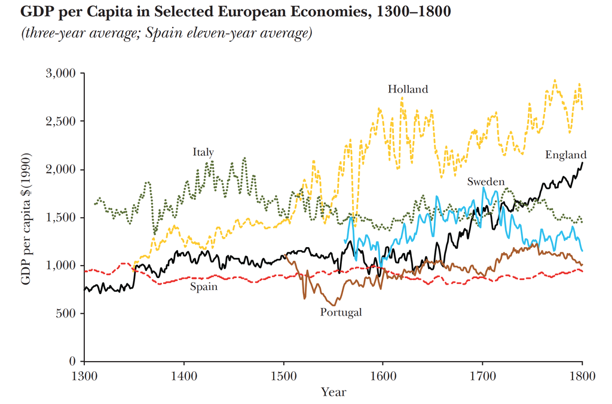

## Post-1800

After 1800 we see “modern economic growth”:

- Sustained increase in GDP per-capita;
- Driven by a technological change.

This begins in England with the Industrial Revolution.

[interactive chart not shown]

## Industrial revolution.

Before 1800, nearly all energy came from biomass.

The industrial revolution allowed humans to harness other forms of energy.

Science and technological development eventually culminated in an unprecedented control and exploitation of nature.

The combination of increased access to energy and technological progress led to rapid, sustained productivity growth.

[interactive chart not shown]

## The Great Divergence

Before 1800:

- Europe and Asia had broadly similar living standards and GDP per-capita.

After 1800:

- Europe took off in terms of wealth, power, and (eventually) living standards;
- Facilitated the domination and colonization of Africa and Asia by European powers;
- Asia (especially India) *de-industrialized* in the 19th century.

## Why Europe?

Some theories for why north-western Europe industrialized:

- High wages relative to the cost of capital (Robert Allen);
- Culture and ideology, with a focus on science and technology (Joel Mokyr);
- Colonial profits (Eric Williams);
- Institutions and property rights (Douglas North).

But who knows…

## The First Globalization

From 1870-1914:

[figure not shown]

## Trivia

By market capitalization, what is/was the largest company in history?

[figure not shown]

## The First Globalization

In the industrial core:

- intensive economic growth based on manufacturing;

In the periphery (colonies):

- extensive economic growth based on exports;
- typically organized around European-owned plantations and mines using forced labor.

## The First Globalization

Africa, Asia and Latin America focused on low-value production, agriculture and raw materials due to:

- Direct political coercion and colonization;
- Market pressures of comparative advantage.

Countries who resisted market pressures were forced to sign “free-trade” agreements.

[figure not shown]

## Prompt

We model economic growth as a closed system. Do you see any problems with this?

What is the role of international trade in economic growth and development?

What is the role of FDI?

How does the international community constrain policy-makers in developing countries?

## 1914-1945

Not of much interest to growth theorists! More about stabilization…

## 1945-1980

We see:

- Rapid economic growth in Industrialized countries (East and West bloc);
- Including catch-up growth in Germany and Japan;
- Catch-up growth in the USSR and East Asia;
- Growth in poor countries, not less than in richer countries.

[interactive chart not shown]

## 1980-Today

We see:

- Little (sometimes negative) growth in the former USSR;
- Rapid growth in China;
- Growth in most poor countries (e.g. India) but little in Africa;
- Slowdown of growth in developed countries.